# Detecting hidden heterogeneity in single cell RNA-Seq data

## Find marker genes for the detected heterogeneity (SV2).

Here, we find marker genes significantly associated with SV2 (multiple testing adjusted p-value < 0.05, default significance cutoff) and having a high R-squared value (R-squared > 0.3, default R-squared cutoff) using the find.markers() function.

```r
marker.counts <- find.markers(t(counts), as.matrix(iasva.sv[,2]))
```

```
## # of markers (): 105
## total # of unique markers:  105
```

```r
nrow(marker.counts)
```

```
## [1] 105
```

```r
anno.col <- data.frame(Cell_Type=Cell_Type)
rownames(anno.col) <- colnames(marker.counts)
head(anno.col)
```

```
##             Cell_Type
## 4th-C63_S30     Cell2
## 4th-C66_S36     Cell2
## 4th-C18_S31     Cell2
## 4th-C57_S18     Cell1
## 4th-C56_S17     Cell2
## 4th-C68_S41     Cell2
```

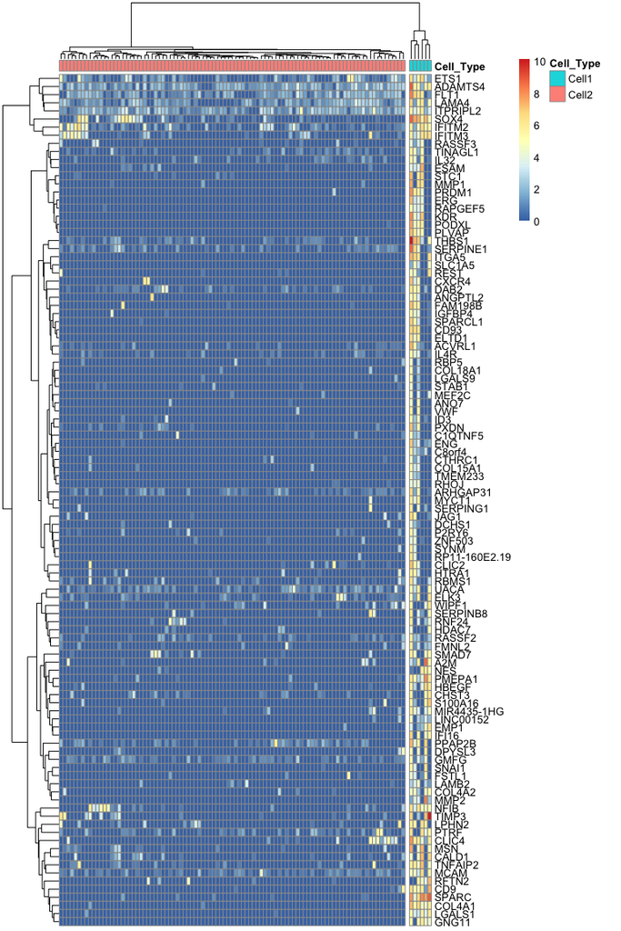

```r
pheatmap(log(marker.counts+1), show_colnames =FALSE, clustering_method = "ward.D2",cutree_cols = 2,annotation_col = anno.col)
```

## Run tSNE to detect the hidden heterogeneity (SV2).

For comparison purpose, here we applied tSNE on read counts of all genes to identify the hidden heterogeneity. We used the Rtsne R package with default settings.

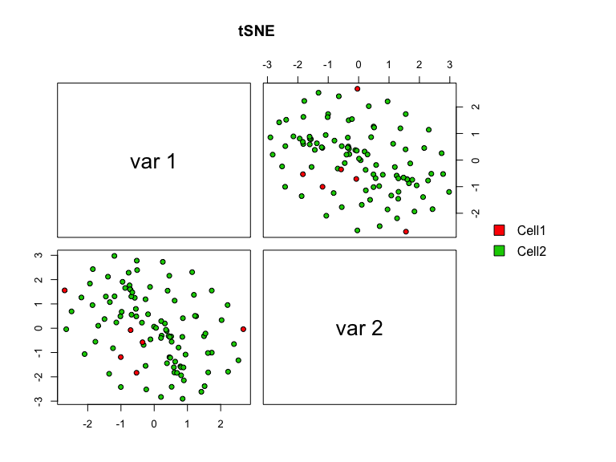

```r
tsne.res <- Rtsne(t(lcounts), dims = 2)
pairs(tsne.res$Y, main="tSNE", pch=21, bg=c("red","green3")[Cell_Type], oma=c(4,4,6,12)) #4,4,6,12
legend(0.8, 0.55, levels(Cell_Type), fill=c("red", "green3"), bty="n")
```

As shown above, tSNE couldn’t detect the outlying cells identified by IA-SVA

## Run tSNE post IA-SVA, i.e., run tSNE on maker genes for SV2 obtained from IA-SVA.

Here, we apply tSNE on the marker genes for SV2 obtained from IA-SVA

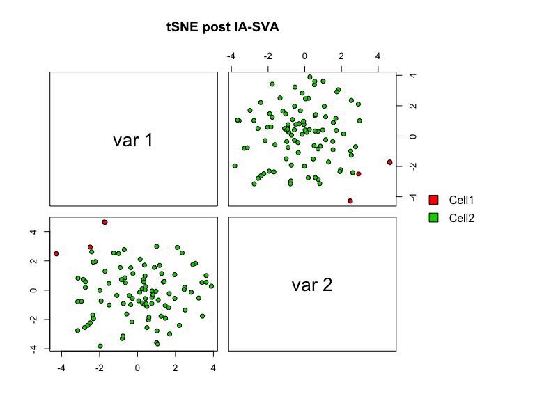

```r
tsne.res <- Rtsne(unique(t(log(marker.counts+1))), dims = 2)
pairs(tsne.res$Y, main="tSNE post IA-SVA", pch=21, bg=c("red","green3")[Cell_Type], oma=c(4,4,6,12)) #4,4,6,12
legend(0.8, 0.55, levels(Cell_Type), fill=c("red", "green3"), bty="n")
```

tSNE post IA-SVA perform better than regular tSNE applied on read counts of entire genes.

## Run principal component analysis (PCA) to detect the hidden heterogeneity (SV2).

Here, we use PCA to detect the hidden heterogeneity detected by IA-SVA.

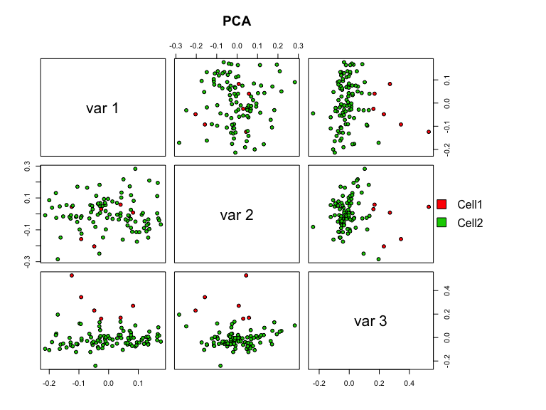

```r
pca_res = svd(lcounts - rowMeans(lcounts))$v
pairs(pca.res[,1:3], main="PCA", pch=21, bg=c("red","green3")[Cell_Type], oma=c(4,4,6,12)) #4,4,6,12
legend(0.8, 0.55, levels(Cell_Type), fill=c("red", "green3"), bty="n")
```

Separation of the six outlying cells by var3 (PC3) is not as clear as one observed from IA-SVA results.

## Run surrogate variable analysis (SVA) to detect the hidden heterogeneity (SV2).

Here, we use SVA to detect the hidden heterogeneity detected by IA-SVA.

```r
mod1 <- model.matrix(~Patient_ID+Geo_Lib_Size)
mod0 <- cbind(mod1[,1])

sva.res = svaseq(counts,mod1,mod0, n.sv=3)$sv
```

```
## Number of significant surrogate variables is:  3
## Iteration (out of 5 ):1  2  3  4  5
```

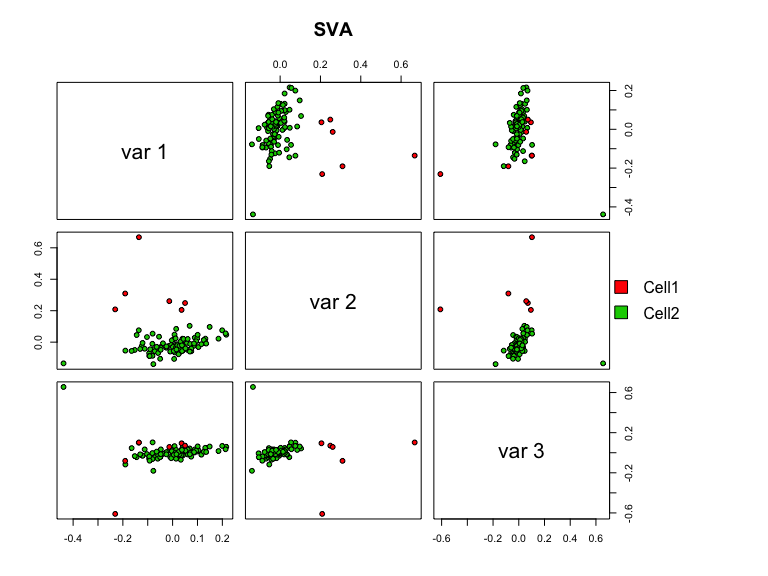

```r
##plot(sva.res[,1], sva.res[,2], xlab="SV1", ylab="SV2", col=Cell_Type)
pairs(sva.res[,1:3], main="SVA", pch=21, bg=c("red","green3")[Cell_Type], oma=c(4,4,6,12)) #4,4,6,12
legend(0.8, 0.55, levels(Cell_Type), fill=c("red", "green3"), bty="n")
```

Again, separation of the six outlying cells by var2 (SV2) is not as clear as one from IA-SVA.